# PCA-Based Policy Indices

## 1 Introduction

This analysis investigates the relationship between gun policies and firearm mortality rates across U.S. states. Prior research suggests that certain policy approaches may be associated with lower rates of gun violence, but there has been limited work using data-driven approaches to identify which policy domains have the strongest protective associations.

In this study, we use Principal Component Analysis (PCA) to identify natural groupings of gun policies and then apply logistic regression to assess how these policy domains relate to firearm mortality outcomes. This approach allows us to move beyond subjective policy groupings to statistical categorizations that better reflect how these policies cluster in practice.

## 2 Data Preparation

We begin by loading the dataset containing state-level information on firearm mortality rates and various gun policy indicators. We then create a binary outcome variable representing whether a state’s firearm mortality rate is above or below the median.

```python
# Load necessary libraries
import pandas as pd
import numpy as np
import matplotlib.pyplot as plt
import seaborn as sns
from sklearn.preprocessing import StandardScaler
from sklearn.model_selection import train_test_split, cross_val_score
from sklearn.linear_model import LogisticRegression
from sklearn.impute import SimpleImputer
from sklearn.metrics import (accuracy_score, precision_score, recall_score,
                            f1_score, roc_curve, auc, confusion_matrix,
                            classification_report)

# Set plotting style
plt.style.use('seaborn-v0_8-whitegrid')
sns.set_palette("colorblind")
plt.rcParams.update({'font.size': 8})  # Reduce font size globally

# Load the dataset
df = pd.read_csv("data/merged_data.csv")

# Create a binary target variable for firearm mortality
df["firearm_mortality_above_median"] = (
    df["firearm_mortality_by_state_2022"] >
    df["firearm_mortality_by_state_2022"].median()
).astype(int)

# Display basic dataset information
print(f"Dataset shape: {df.shape}")
print(f"Number of states with high firearm mortality: {df['firearm_mortality_above_median'].sum()}")
print(f"Number of states with low firearm mortality: {len(df) - df['firearm_mortality_above_median'].sum()}")
```

```
Dataset shape: (51, 63)
Number of states with high firearm mortality: 25
Number of states with low firearm mortality: 26
```

Based on a prior Principal Component Analysis, we identified six natural groupings of gun policies. These groupings better reflect the statistical relationships among policies than arbitrary categorizations.

```python
# Define PCA-based composite indices
pca_based_indices = {
    # Group 1: Weapon and Purchase Restrictions
    'weapon_purchase_restrictions_index': [
        'high_capacity_magazines_prohibited',
        'asault_weapons_prohibited',
        'background_check_or_purchase_permit',
        'dealer_lisence_required',
        'waiting_period',
        'age_requirement'
    ],

    # Group 2: Risk-Based Intervention
    'risk_intervention_index': [
        'red_flag_laws',
        'extreme_risk_law',
        'gun_removal_program',
        'rejected_shoot_first_laws'
    ],

    # Group 3: Domestic Violence Prevention
    'domestic_violence_prevention_index': [
        'prohibition_for_stalkers',
        'prohibition_for_domestic_abusers',
        'prohibition_for_convicted_domestic_abusers',
        'abusers_turn_in_gun_after_conviction',
        'restraining_order_prohibitor'
    ],

    # Group 4: High-Risk Individual Prohibitions
    'high_risk_individual_index': [
        'felony_prohibitor',
        'fugitive_from_justice_prohibitor',
        'mentaI_illness_prohibitor',
        'hate_crime_prohibitor',
        'no_purchase_after_violent_offense',
        'mental_health_in_background_check'
    ],

    # Group 5: Location-Based Restrictions
    'location_restrictions_index': [
        'no_open_carry',
        'concealed_carry_permit_required',
        'no_guns_in_k_through_twelve_schools',
        'no_guns_at_demonstrations',
        'no_guns_on_college_campuses',
        'bar_concealed_carry_by_people_with_violent_misdemeanors'
    ],

    # Group 6: Safety Regulations
    'safety_regulations_index': [
        'secure_storage_child_access_laws',
        'funding_for_violence_intervention'
    ]
}

# Function to create composite indices
def create_composite_indices(df, index_definitions):
    df_copy = df.copy()

    for name, columns in index_definitions.items():
        df_copy[name] = df_copy[columns].fillna(0).mean(axis=1)

    return df_copy

# Create dataset with PCA-based indices
df_with_indices = create_composite_indices(df, pca_based_indices)

# Display summary statistics for each index
index_summary = df_with_indices[list(pca_based_indices.keys())].describe()
print("Summary Statistics for Policy Indices:")
index_summary
```

```
Summary Statistics for Policy Indices:
```

|  | weapon_purchase_restrictions_index | risk_intervention_index | domestic_violence_prevention_index | high_risk_individual_index | location_restrictions_index | safety_regulations_index |
| --- | --- | --- | --- | --- | --- | --- |
| count | 51.000000 | 51.000000 | 51.000000 | 51.000000 | 51.000000 | 51.000000 |
| mean | 0.313725 | 0.343137 | 0.458824 | 0.562092 | 0.500000 | 0.656863 |
| std | 0.370656 | 0.396739 | 0.353936 | 0.282766 | 0.316228 | 0.367290 |
| min | 0.000000 | 0.000000 | 0.000000 | 0.000000 | 0.000000 | 0.000000 |
| 25% | 0.000000 | 0.000000 | 0.200000 | 0.333333 | 0.333333 | 0.500000 |
| 50% | 0.166667 | 0.000000 | 0.400000 | 0.666667 | 0.500000 | 0.500000 |
| 75% | 0.583333 | 0.750000 | 0.800000 | 0.666667 | 0.666667 | 1.000000 |
| max | 1.000000 | 1.000000 | 1.000000 | 1.000000 | 1.000000 | 1.000000 |

## 3 Understanding the Policy Domains

The six policy domains identified through PCA represent different approaches to gun policy:

1. **Weapon and Purchase Restrictions**: Policies that control who can purchase firearms and what types of weapons are available (background checks, waiting periods, magazine limits).
2. **Risk-Based Intervention**: Policies that provide mechanisms to temporarily remove firearms from individuals who pose a risk to themselves or others (red flag laws, extreme risk protection orders).
3. **Domestic Violence Prevention**: Policies specifically targeting the intersection of domestic violence and firearms (prohibitions for stalkers, abusers).
4. **High-Risk Individual Prohibitions**: Policies that prevent firearm access for categories of individuals deemed high-risk (felons, fugitives, those with mental illness).
5. **Location-Based Restrictions**: Policies that restrict where firearms can be carried (schools, demonstrations, open carry restrictions).
6. **Safety Regulations**: Policies focused on safe storage and violence prevention programs.

Let’s visualize the distribution of these indices across states:

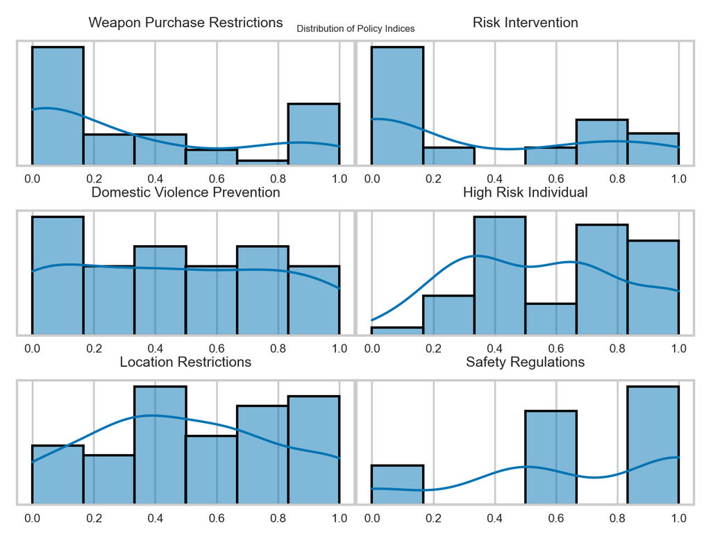

```python
# Visualize the distribution of each policy index with smaller size
fig, axes = plt.subplots(3, 2, figsize=(4, 3))  # Very compact size
axes = axes.flatten()

for i, index_name in enumerate(pca_based_indices.keys()):
    sns.histplot(df_with_indices[index_name], ax=axes[i], kde=True,
                 bins=6, line_kws={'linewidth': 1})  # Fewer bins, thinner lines

    # Smaller title and labels
    axes[i].set_title(index_name.replace('_index', '').replace('_', ' ').title(), fontsize=6)
    axes[i].set_xlabel("", fontsize=5)  # Remove x-label text
    axes[i].set_ylabel("", fontsize=5)  # Remove y-label text

    # Smaller tick labels and fewer ticks
    axes[i].tick_params(axis='both', which='major', labelsize=5)
    axes[i].set_yticks([])  # Remove y-ticks entirely

# Extremely tight spacing
plt.subplots_adjust(left=0.05, right=0.95, bottom=0.05, top=0.90, wspace=0.2, hspace=0.2)
plt.tight_layout(pad=0.1, w_pad=0.1, h_pad=0.1)
plt.suptitle("Distribution of Policy Indices", fontsize=4, y=0.98)
plt.show()
```

## 4 Correlations Between Policy Domains

Before building our predictive model, let’s examine how these policy domains correlate with each other and with firearm mortality rates:

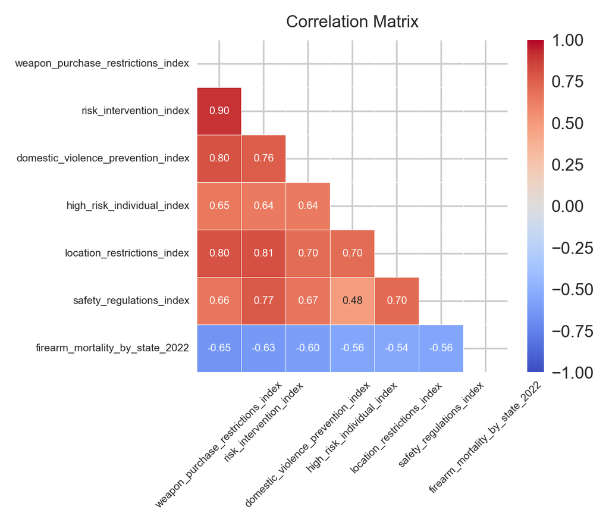

```python
# Calculate correlation matrix
correlation_vars = list(pca_based_indices.keys()) + ['firearm_mortality_by_state_2022']
correlation_matrix = df_with_indices[correlation_vars].corr()

# Plot correlation heatmap with minimal size
plt.figure(figsize=(4, 3.5))
mask = np.triu(np.ones_like(correlation_matrix, dtype=bool))
sns.heatmap(correlation_matrix, mask=mask, annot=True, cmap='coolwarm',
            fmt=".2f", linewidths=0.2, vmin=-1, vmax=1, annot_kws={"size": 5})
plt.title('Correlation Matrix', fontsize=8)
plt.xticks(fontsize=5, rotation=45)
plt.yticks(fontsize=5)
plt.tight_layout()
plt.show()
```

## 5 Logistic Regression Modeling

We’ll build a logistic regression model to predict whether a state has above-median firearm mortality based on its policy index values. We’ll compare three types of logistic regression: standard (no regularization), Lasso (L1 regularization), and Ridge (L2 regularization).

### 5.1 Data Preparation for Modeling

```python
# Prepare data for logistic regression
feature_names = list(pca_based_indices.keys())
X = df_with_indices[feature_names].copy()
y = df_with_indices['firearm_mortality_above_median']

# Handle missing values
imputer = SimpleImputer(strategy="mean")
X_imputed = imputer.fit_transform(X)

# Scale the features
scaler = StandardScaler()
X_scaled = scaler.fit_transform(X_imputed)

# Split data into training and testing sets
X_train, X_test, y_train, y_test = train_test_split(
    X_scaled, y, test_size=0.2, random_state=42, stratify=y
)
```

### 5.2 Model Comparison with Cross-Validation

```
Cross-Validation Results:
Standard: Accuracy = 0.7618 (±0.1376)
Lasso (L1): Accuracy = 0.7818 (±0.1002)
Ridge (L2): Accuracy = 0.7618 (±0.1045)
```

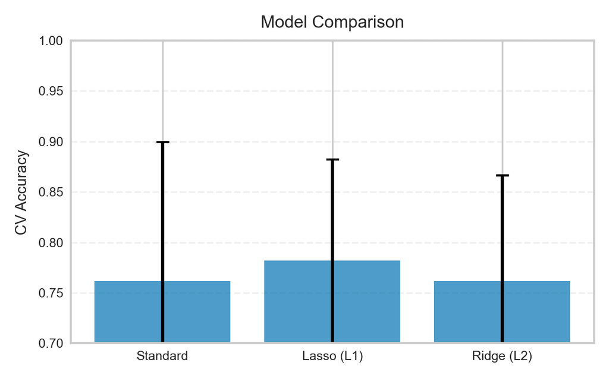

```python
# Compare different logistic regression models
models = {
    "Standard": LogisticRegression(penalty=None, solver="lbfgs", max_iter=1000, random_state=42),
    "Lasso (L1)": LogisticRegression(penalty="l1", solver="liblinear", max_iter=1000, random_state=42),
    "Ridge (L2)": LogisticRegression(penalty="l2", solver="liblinear", max_iter=1000, random_state=42)
}

# Evaluate models with cross-validation
print("Cross-Validation Results:")
cv_results = {}
for name, model in models.items():
    # Perform cross-validation
    cv_scores = cross_val_score(model, X_scaled, y, cv=5, scoring="accuracy")
    cv_results[name] = {
        "Mean Accuracy": np.mean(cv_scores),
        "Std Dev": np.std(cv_scores)
    }
    print(f"{name}: Accuracy = {np.mean(cv_scores):.4f} (±{np.std(cv_scores):.4f})")

# Visualize cross-validation results - much more compact
plt.figure(figsize=(4, 2.5))
models_names = list(cv_results.keys())
accuracies = [cv_results[name]["Mean Accuracy"] for name in models_names]
std_devs = [cv_results[name]["Std Dev"] for name in models_names]

plt.bar(models_names, accuracies, yerr=std_devs, capsize=3, alpha=0.7)
plt.ylabel('CV Accuracy', fontsize=7)
plt.title('Model Comparison', fontsize=8)
plt.ylim(0.7, 1.0)  # Adjusted to zoom in on relevant range
plt.grid(axis='y', linestyle='--', alpha=0.3)
plt.xticks(fontsize=6)
plt.yticks(fontsize=6)
plt.tight_layout()
plt.show()
```

Based on the cross-validation results, Lasso (L1) Logistic Regression performs best. We’ll use this model for our final evaluation.

### 5.3 Final Model Training and Evaluation

```python
# Use the best model (based on CV results) for final fitting
best_model = LogisticRegression(penalty="l1", solver="liblinear", max_iter=1000, random_state=42)
best_model.fit(X_train, y_train)

# Make predictions
y_pred = best_model.predict(X_test)
y_prob = best_model.predict_proba(X_test)[:, 1]

# Calculate and display performance metrics
print("\nTest Set Performance:")
print(f"Accuracy: {accuracy_score(y_test, y_pred):.4f}")
print(f"Precision: {precision_score(y_test, y_pred):.4f}")
print(f"Recall: {recall_score(y_test, y_pred):.4f}")
print(f"F1 Score: {f1_score(y_test, y_pred):.4f}")
roc_auc = auc(*roc_curve(y_test, y_prob)[:2])
print(f"ROC AUC: {roc_auc:.4f}")

# Print classification report
print("\nClassification Report:")
print(classification_report(y_test, y_pred))
```

```
Test Set Performance:
Accuracy: 0.6364
Precision: 0.5714
Recall: 0.8000
F1 Score: 0.6667
ROC AUC: 0.8667

Classification Report:
              precision    recall  f1-score   support

           0       0.75      0.50      0.60         6
           1       0.57      0.80      0.67         5

    accuracy                           0.64        11
   macro avg       0.66      0.65      0.63        11
weighted avg       0.67      0.64      0.63        11
```

### 5.4 Model Performance Visualization

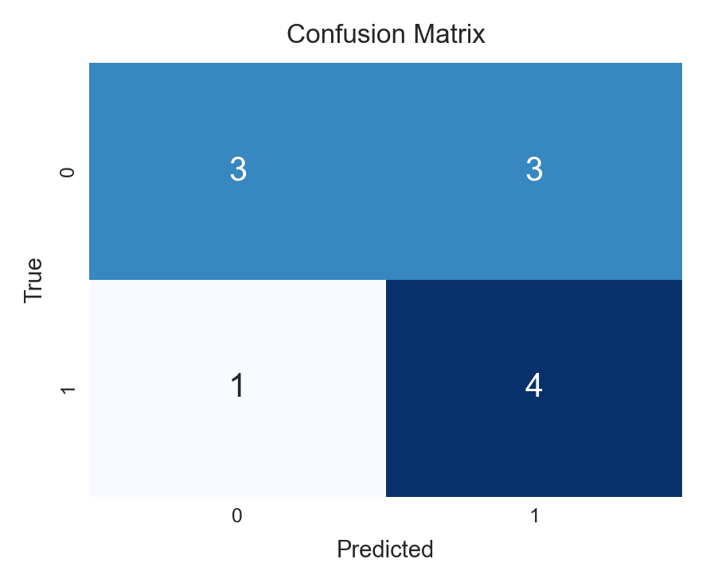

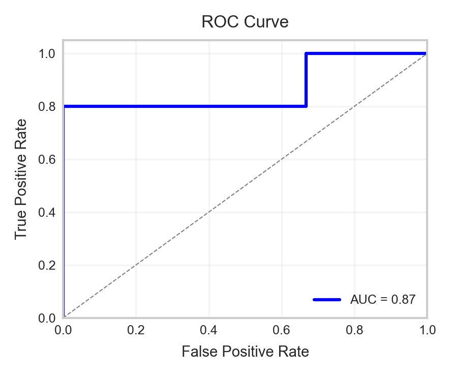

```python
# Plot confusion matrix (much smaller)
plt.figure(figsize=(3, 2.5))
cm = confusion_matrix(y_test, y_pred)
sns.heatmap(cm, annot=True, fmt='d', cmap='Blues', cbar=False, annot_kws={"size": 10})
plt.xlabel('Predicted', fontsize=7)
plt.ylabel('True', fontsize=7)
plt.title('Confusion Matrix', fontsize=8)
plt.xticks(fontsize=6)
plt.yticks(fontsize=6)
plt.tight_layout()
plt.show()

# Plot ROC curve (much smaller)
plt.figure(figsize=(3, 2.5))
fpr, tpr, _ = roc_curve(y_test, y_prob)
plt.plot(fpr, tpr, color='blue', lw=1.5, label=f'AUC = {roc_auc:.2f}')
plt.plot([0, 1], [0, 1], color='gray', linestyle='--', lw=0.5)
plt.xlim([0.0, 1.0])
plt.ylim([0.0, 1.05])
plt.xlabel('False Positive Rate', fontsize=7)
plt.ylabel('True Positive Rate', fontsize=7)
plt.title('ROC Curve', fontsize=8)
plt.legend(loc="lower right", fontsize=6)
plt.grid(alpha=0.2)
plt.xticks(fontsize=6)
plt.yticks(fontsize=6)
plt.tight_layout()
plt.show()
```

## 6 Feature Importance Analysis

One of the key advantages of using Lasso regression is that it helps identify the most important features by shrinking less important coefficients to zero. Let’s analyze which policy domains have the strongest associations with firearm mortality:

```python
# Feature importance analysis
coefficients = best_model.coef_[0]
importance_df = pd.DataFrame({
    'Feature': feature_names,
    'Coefficient': coefficients,
    'Abs_Coefficient': np.abs(coefficients)
}).sort_values('Abs_Coefficient', ascending=False)

# Add interpretation column
importance_df['Effect'] = ['Increases Mortality Risk' if c > 0 else 'Decreases Mortality Risk'
                         for c in importance_df['Coefficient']]

print("\nFeature Importance:")
print(importance_df)
```

```
Feature Importance:
                              Feature  Coefficient  Abs_Coefficient  \
0  weapon_purchase_restrictions_index    -1.209084         1.209084
5            safety_regulations_index    -0.604965         0.604965
3          high_risk_individual_index    -0.367641         0.367641
4         location_restrictions_index     0.169691         0.169691
1             risk_intervention_index     0.000000         0.000000
2  domestic_violence_prevention_index     0.000000         0.000000

                     Effect
0  Decreases Mortality Risk
5  Decreases Mortality Risk
3  Decreases Mortality Risk
4  Increases Mortality Risk
1  Decreases Mortality Risk
2  Decreases Mortality Risk
```

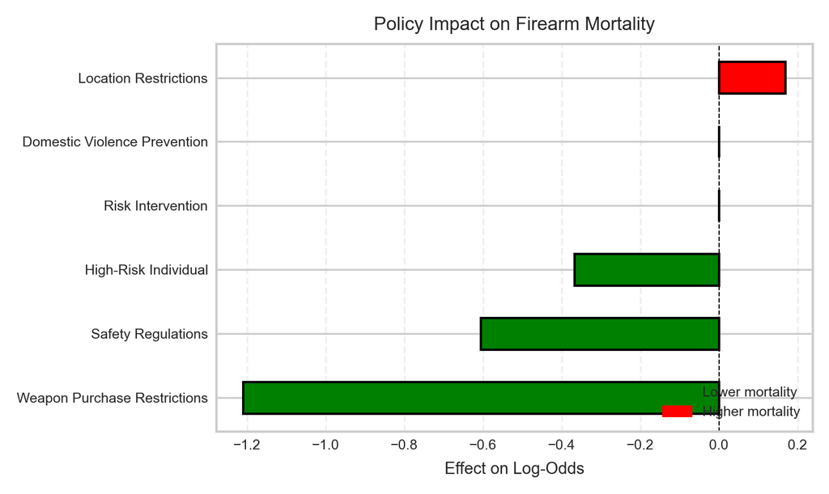

```python
# Create a mapping for cleaner feature names
clean_names = {
    'domestic_violence_prevention_index': 'Domestic Violence Prevention',
    'risk_intervention_index': 'Risk Intervention',
    'location_restrictions_index': 'Location Restrictions',
    'high_risk_individual_index': 'High-Risk Individual',
    'safety_regulations_index': 'Safety Regulations',
    'weapon_purchase_restrictions_index': 'Weapon Purchase Restrictions'
}

# Apply mapping to DataFrame
importance_df['Clean Feature'] = importance_df['Feature'].map(clean_names)

# Sort by coefficient value for better visualization
importance_df = importance_df.sort_values('Coefficient')

# Set colors
colors = ['red' if coef > 0 else 'green' for coef in importance_df['Coefficient']]

# Plot - much more compact
plt.figure(figsize=(5, 3))
plt.barh(
    importance_df['Clean Feature'],
    importance_df['Coefficient'],
    color=colors,
    edgecolor='black',
    height=0.5  # Thinner bars
)

# Simplified aesthetics
plt.axvline(x=0, color='black', linestyle='--', linewidth=0.5)
plt.xlabel('Effect on Log-Odds', fontsize=7)
plt.title('Policy Impact on Firearm Mortality', fontsize=8)
plt.grid(axis='x', linestyle='--', alpha=0.3)
plt.xticks(fontsize=6)
plt.yticks(fontsize=6)

# Add a small legend instead of caption
plt.legend([plt.Rectangle((0,0),1,1, color='green'),
            plt.Rectangle((0,0),1,1, color='red')],
           ['Lower mortality', 'Higher mortality'],
           fontsize=6, loc='lower right')

plt.tight_layout()
plt.show()
```

## 7 Discussion and Interpretation

Our analysis reveals several key findings about the relationship between gun policies and firearm mortality:

1. **Weapon Purchase Restrictions**: This domain shows the strongest protective association with firearm mortality. States with more comprehensive purchase restrictions (including background checks, waiting periods, dealer licensing, and assault weapon bans) tend to have significantly lower firearm mortality rates.
2. **Safety Regulations**: The second most important factor, also showing a substantial protective effect. This includes secure storage laws and funding for violence intervention programs.
3. **High-Risk Individual Prohibitions**: These policies also show a moderate protective association, suggesting that limiting gun access for high-risk individuals (such as those with felony convictions or mental illness) may help reduce mortality.
4. **Location Restrictions**: Interestingly, this is the only domain with a positive coefficient, suggesting that location-based restrictions might be associated with slightly higher mortality rates. This could reflect that these policies might be reactive (implemented in response to existing violence) rather than preventive.
5. **Risk Intervention** and **Domestic Violence Prevention**: These domains were eliminated by the Lasso regression (coefficients set to zero), suggesting that after accounting for the other policy domains, they don’t add significant predictive power. This doesn’t necessarily mean these policies are ineffective, but rather that their effects might already be captured by the other indices.

The model shows good discrimination ability with an AUC of 0.87, suggesting that these policy domains together provide meaningful predictive power for firearm mortality outcomes.

## 8 Limitations

Several limitations should be considered when interpreting these results:

1. **Causality**: This analysis identifies associations but cannot establish causality. States with lower firearm mortality might be more likely to implement certain policies, rather than the policies causing the lower mortality.
2. **Small Sample Size**: With only 50 states (plus DC), the statistical power is limited, especially for the test set evaluation.
3. **Implementation Quality**: Our indices measure the presence of policies but not how well they are implemented or enforced.
4. **Confounding Factors**: Many other factors beyond gun policies influence firearm mortality, including socioeconomic conditions, healthcare access, and cultural factors.

## 9 Conclusion

This data-driven analysis suggests that comprehensive weapon purchase restrictions may be the most promising policy approach for reducing firearm mortality, followed by safety regulations and high-risk individual prohibitions. Future research should examine the causal mechanisms behind these associations and how policy implementation affects outcomes.

The use of PCA-based policy groupings provides a novel approach to understanding how gun policies naturally cluster and relate to mortality outcomes, moving beyond subjective categorizations to data-driven insights.